# Project: Investigate a Dataset - [No-show appointments]

- Introduction
- Data Wrangling
- Exploratory Data Analysis
- Conclusions

## Introduction

This dataset collects information from 100k medical appointments in Brazil and is focused on the question of whether or not patients show up for their appointment. A number of characteristics about the patient are included in each row.

- **`PatientId`**: indicates the patient ID; duplication is possible due to cases where the same patient booked more than one appointment.
- **`AppointmentID`**: indicates appoint ID, this field should be unique
- **`Gender`**: indicates the patient's gender (M/F)
- **`ScheduledDay`**: indicates the Date/Time the patient set up their appointment.
- **`AppointmentDay`**: indicates the date/time the patient called to book their appointment.
- **`Age`**: indicates the patient's age.
- **`Neighborhood`**: indicates the location of the hospital.
- **`Scholarship`**: indicates whether or not the patient is enrolled in Brasilian welfare program Bolsa Família.
- **`Hipertension`**: indicates whether or not the patient is experiencing Hypertension.
- **`Diabetes`**: indicates whether or not the patient is experiencing Diabetes.
- **`Alcoholism`**: indicates whether or not the patient is experiencing Alcoholism.
- **`Handcap`**: indicates whether or not the patient is with special needs.
- **`SMS_received`**: indicates whether or not the patient has received a reminder text message.
- **`No-show`**: ‘No’ if the patient showed up to their appointment, and ‘Yes’ if they did not show up.

```python
# Use this cell to set up import statements for all of the packages that you
#   plan to use.

import numpy as np
import pandas as pd
import matplotlib.pyplot as plt
import seaborn as sns

# Remember to include a 'magic word' so that your visualizations are plotted
#   inline with the notebook. See this page for more:
#   http://ipython.readthedocs.io/en/stable/interactive/magics.html

%matplotlib inline
```

## Data Wrangling

> **Tip**: In this section of the report, you will load in the data, check for cleanliness, and then trim and clean your dataset for analysis. Make sure that you document your steps carefully and justify your cleaning decisions.

### General Properties (Dataset dimensions, columns/ rows/ data types)

```python
# Load your data and print out a few lines. Perform operations to inspect data
#   types and look for instances of missing or possibly errant data.

df = pd.read_csv('noshowappointments-kagglev2-may-2016.csv')
df.head()
```

|  | PatientId | AppointmentID | Gender | ScheduledDay | AppointmentDay | Age | Neighbourhood | Scholarship | Hipertension | Diabetes | Alcoholism | Handcap | SMS_received | No-show |
| --- | --- | --- | --- | --- | --- | --- | --- | --- | --- | --- | --- | --- | --- | --- |
| 0 | 2.987250e+13 | 5642903 | F | 2016-04-29T18:38:08Z | 2016-04-29T00:00:00Z | 62 | JARDIM DA PENHA | 0 | 1 | 0 | 0 | 0 | 0 | No |
| 1 | 5.589978e+14 | 5642503 | M | 2016-04-29T16:08:27Z | 2016-04-29T00:00:00Z | 56 | JARDIM DA PENHA | 0 | 0 | 0 | 0 | 0 | 0 | No |
| 2 | 4.262962e+12 | 5642549 | F | 2016-04-29T16:19:04Z | 2016-04-29T00:00:00Z | 62 | MATA DA PRAIA | 0 | 0 | 0 | 0 | 0 | 0 | No |
| 3 | 8.679512e+11 | 5642828 | F | 2016-04-29T17:29:31Z | 2016-04-29T00:00:00Z | 8 | PONTAL DE CAMBURI | 0 | 0 | 0 | 0 | 0 | 0 | No |
| 4 | 8.841186e+12 | 5642494 | F | 2016-04-29T16:07:23Z | 2016-04-29T00:00:00Z | 56 | JARDIM DA PENHA | 0 | 1 | 1 | 0 | 0 | 0 | No |

```python
df.shape
```

```
(110527, 14)
```

```python
df.info()
```

```
<class 'pandas.core.frame.DataFrame'>
RangeIndex: 110527 entries, 0 to 110526
Data columns (total 14 columns):
 #   Column          Non-Null Count   Dtype
---  ------          --------------   -----
 0   PatientId       110527 non-null  float64
 1   AppointmentID   110527 non-null  int64
 2   Gender          110527 non-null  object
 3   ScheduledDay    110527 non-null  object
 4   AppointmentDay  110527 non-null  object
 5   Age             110527 non-null  int64
 6   Neighbourhood   110527 non-null  object
 7   Scholarship     110527 non-null  int64
 8   Hipertension    110527 non-null  int64
 9   Diabetes        110527 non-null  int64
 10  Alcoholism      110527 non-null  int64
 11  Handcap         110527 non-null  int64
 12  SMS_received    110527 non-null  int64
 13  No-show         110527 non-null  object
dtypes: float64(1), int64(8), object(5)
memory usage: 11.8+ MB
```

No missing data

```python
df.describe()
```

|  | PatientId | AppointmentID | Age | Scholarship | Hipertension | Diabetes | Alcoholism | Handcap | SMS_received |
| --- | --- | --- | --- | --- | --- | --- | --- | --- | --- |
| count | 1.105270e+05 | 1.105270e+05 | 110527.000000 | 110527.000000 | 110527.000000 | 110527.000000 | 110527.000000 | 110527.000000 | 110527.000000 |
| mean | 1.474963e+14 | 5.675305e+06 | 37.088874 | 0.098266 | 0.197246 | 0.071865 | 0.030400 | 0.022248 | 0.321026 |
| std | 2.560949e+14 | 7.129575e+04 | 23.110205 | 0.297675 | 0.397921 | 0.258265 | 0.171686 | 0.161543 | 0.466873 |
| min | 3.921784e+04 | 5.030230e+06 | -1.000000 | 0.000000 | 0.000000 | 0.000000 | 0.000000 | 0.000000 | 0.000000 |
| 25% | 4.172614e+12 | 5.640286e+06 | 18.000000 | 0.000000 | 0.000000 | 0.000000 | 0.000000 | 0.000000 | 0.000000 |
| 50% | 3.173184e+13 | 5.680573e+06 | 37.000000 | 0.000000 | 0.000000 | 0.000000 | 0.000000 | 0.000000 | 0.000000 |
| 75% | 9.439172e+13 | 5.725524e+06 | 55.000000 | 0.000000 | 0.000000 | 0.000000 | 0.000000 | 0.000000 | 1.000000 |
| max | 9.999816e+14 | 5.790484e+06 | 115.000000 | 1.000000 | 1.000000 | 1.000000 | 1.000000 | 4.000000 | 1.000000 |

- The mean of ages is 37 years.
- Maximum age is 115 years.
- There is probably a mistake with one of the patient's age. It shows -1 year, which does not make sense.

### Data Cleaning

```python
# Rename columns to facilitate analysis
df.columns = ['PatientID', 'AppointmentID', 'Gender', 'ScheduledDay',
       'AppointmentDay', 'Age', 'Neighbourhood', 'Scholarship', 'Hypertension',
       'Diabetes', 'Alcoholism', 'Handicap', 'SMS_received', 'ShowStatus']
```

```python
# We won't need the patient ID, Appointment ID, ScheduledDay and AppointmentDay in our data analysis
df.drop(['PatientID', 'AppointmentID', 'ScheduledDay', 'AppointmentDay'], axis =1 ,inplace=True)
df.head()
```

|  | Gender | Age | Neighbourhood | Scholarship | Hypertension | Diabetes | Alcoholism | Handicap | SMS_received | ShowStatus |
| --- | --- | --- | --- | --- | --- | --- | --- | --- | --- | --- |
| 0 | F | 62 | JARDIM DA PENHA | 0 | 1 | 0 | 0 | 0 | 0 | No |
| 1 | M | 56 | JARDIM DA PENHA | 0 | 0 | 0 | 0 | 0 | 0 | No |
| 2 | F | 62 | MATA DA PRAIA | 0 | 0 | 0 | 0 | 0 | 0 | No |
| 3 | F | 8 | PONTAL DE CAMBURI | 0 | 0 | 0 | 0 | 0 | 0 | No |
| 4 | F | 56 | JARDIM DA PENHA | 0 | 1 | 1 | 0 | 0 | 0 | No |

## Exploratory Data Analysis

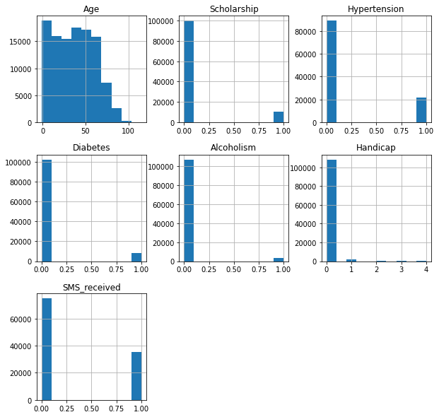

```python
df.hist(figsize = (10,10));
```

### Questions

1. What is the overall appointment show-up vs. no show-up rate?
2. What is the relationship of various categories within each variable and the show-up rates?

### Research Question 1: What is the overall appointment show-up vs. no show-up rate?

```python
#first, split appointment show-up
show = df.ShowStatus == 'No'
noshow = df.ShowStatus == 'Yes'
```

```python
df[show].describe()
```

|  | Age | Scholarship | Hypertension | Diabetes | Alcoholism | Handicap | SMS_received |
| --- | --- | --- | --- | --- | --- | --- | --- |
| count | 88208.000000 | 88208.000000 | 88208.000000 | 88208.000000 | 88208.000000 | 88208.000000 | 88208.000000 |
| mean | 37.790064 | 0.093903 | 0.204392 | 0.073837 | 0.030417 | 0.022742 | 0.291334 |
| std | 23.338878 | 0.291695 | 0.403259 | 0.261507 | 0.171732 | 0.162750 | 0.454380 |
| min | -1.000000 | 0.000000 | 0.000000 | 0.000000 | 0.000000 | 0.000000 | 0.000000 |
| 25% | 18.000000 | 0.000000 | 0.000000 | 0.000000 | 0.000000 | 0.000000 | 0.000000 |
| 50% | 38.000000 | 0.000000 | 0.000000 | 0.000000 | 0.000000 | 0.000000 | 0.000000 |
| 75% | 56.000000 | 0.000000 | 0.000000 | 0.000000 | 0.000000 | 0.000000 | 1.000000 |
| max | 115.000000 | 1.000000 | 1.000000 | 1.000000 | 1.000000 | 4.000000 | 1.000000 |

```python
df[noshow].describe()
```

|  | Age | Scholarship | Hypertension | Diabetes | Alcoholism | Handicap | SMS_received |
| --- | --- | --- | --- | --- | --- | --- | --- |
| count | 22319.000000 | 22319.000000 | 22319.000000 | 22319.000000 | 22319.000000 | 22319.000000 | 22319.000000 |
| mean | 34.317667 | 0.115507 | 0.169004 | 0.064071 | 0.030333 | 0.020297 | 0.438371 |
| std | 21.965941 | 0.319640 | 0.374764 | 0.244885 | 0.171505 | 0.156670 | 0.496198 |
| min | 0.000000 | 0.000000 | 0.000000 | 0.000000 | 0.000000 | 0.000000 | 0.000000 |
| 25% | 16.000000 | 0.000000 | 0.000000 | 0.000000 | 0.000000 | 0.000000 | 0.000000 |
| 50% | 33.000000 | 0.000000 | 0.000000 | 0.000000 | 0.000000 | 0.000000 | 0.000000 |
| 75% | 51.000000 | 0.000000 | 0.000000 | 0.000000 | 0.000000 | 0.000000 | 1.000000 |
| max | 115.000000 | 1.000000 | 1.000000 | 1.000000 | 1.000000 | 4.000000 | 1.000000 |

The number of who showed 4 times who did not show

### Research Question #2: What is the relationship of various categories within each variable and the show-up rates?

#### 1- Gender

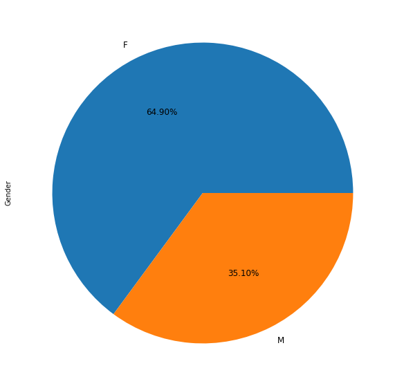

```python
df_pie = df.Gender[show].value_counts()
ax = df_pie.plot.pie(figsize=(10,10), autopct='%1.2f%%', fontsize = 12);
```

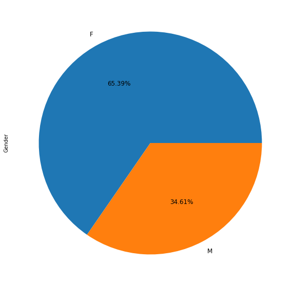

```python
df_pie = df.Gender[noshow].value_counts()
ax = df_pie.plot.pie(figsize=(10,10), autopct='%1.2f%%', fontsize = 12);
```

Gender didn't make a difference, either way who showed-up and didn't show up, Women are also more than them.

#### 2- Age

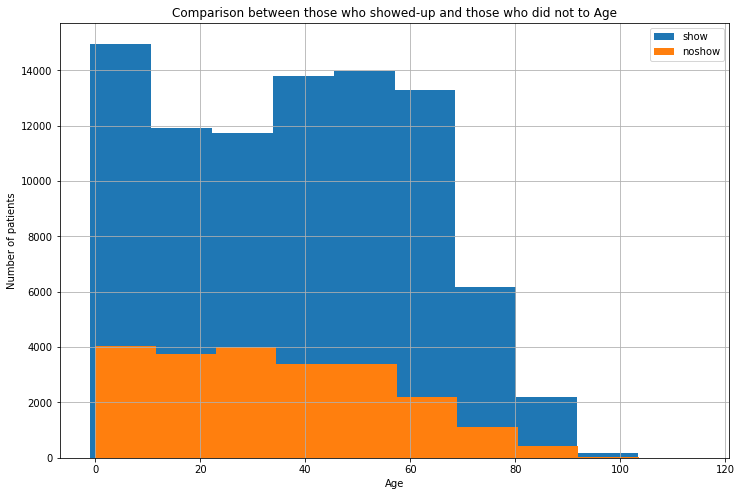

```python
plt.figure(figsize=[12,8])
df.Age[show].hist(label = 'show')
df.Age[noshow].hist(label = 'noshow')
plt.legend()

plt.title('Comparison between those who showed-up and those who did not to Age')
plt.xlabel('Age')
plt.ylabel('Number of patients');
```

#### 3- Neighborhood

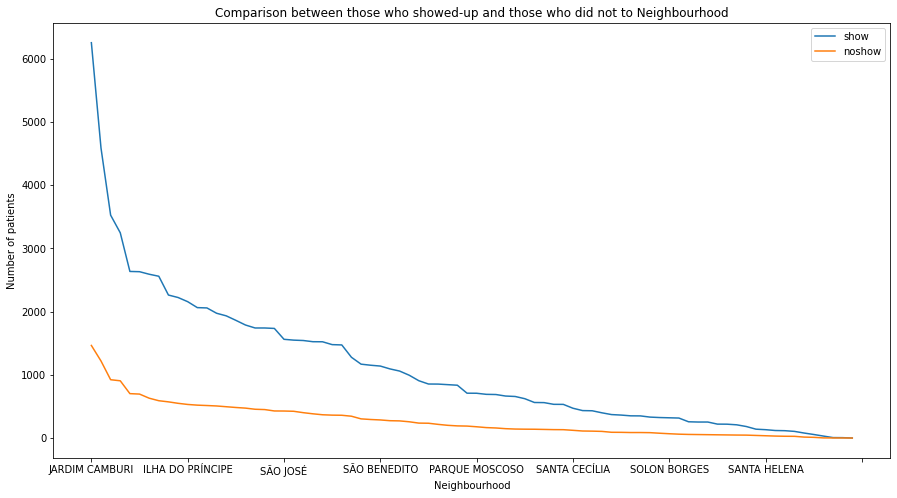

```python
plt.figure(figsize=[15,8])
df.Neighbourhood[show].value_counts().plot(label = 'show')
df.Neighbourhood[noshow].value_counts().plot(label = 'noshow')
plt.legend()

plt.title('Comparison between those who showed-up and those who did not to Neighbourhood')
plt.xlabel('Neighbourhood')
plt.ylabel('Number of patients');
```

#### 4- Scholarship

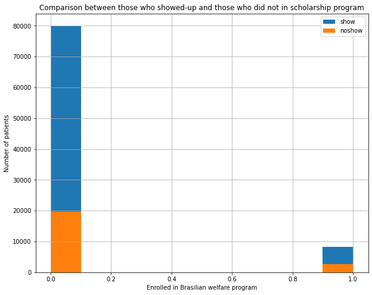

```python
plt.figure(figsize=[10,8])
df.Scholarship[show].hist(label = 'show')
df.Scholarship[noshow].hist(label = 'noshow')
plt.legend()

plt.title('Comparison between those who showed-up and those who did not in scholarship program')
plt.xlabel('Enrolled in Brasilian welfare program')
plt.ylabel('Number of patients');
```

Scholarship also does not have a strong effect.

#### 5- Hypertension

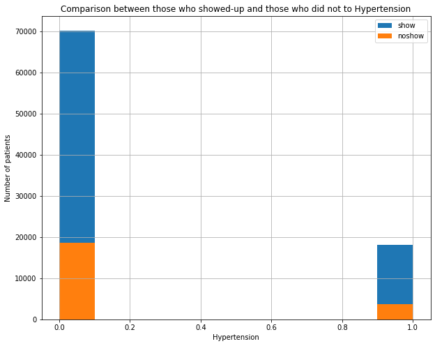

```python
plt.figure(figsize=[10,8])
df.Hypertension[show].hist(label = 'show')
df.Hypertension[noshow].hist(label = 'noshow')
plt.legend()

plt.title('Comparison between those who showed-up and those who did not to Hypertension')
plt.xlabel('Hypertension')
plt.ylabel('Number of patients');
```

Hypertension rate is normal

#### 6- Diabetes

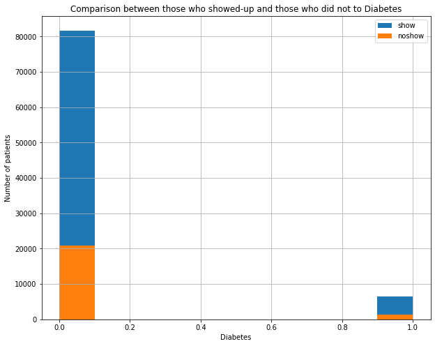

```python
plt.figure(figsize=[10,8])
df.Diabetes[show].hist(label = 'show')
df.Diabetes[noshow].hist(label = 'noshow')
plt.legend()

plt.title('Comparison between those who showed-up and those who did not to Diabetes')
plt.xlabel('Diabetes')
plt.ylabel('Number of patients');
```

Diabetes rate is normal

#### 7- Alcoholism

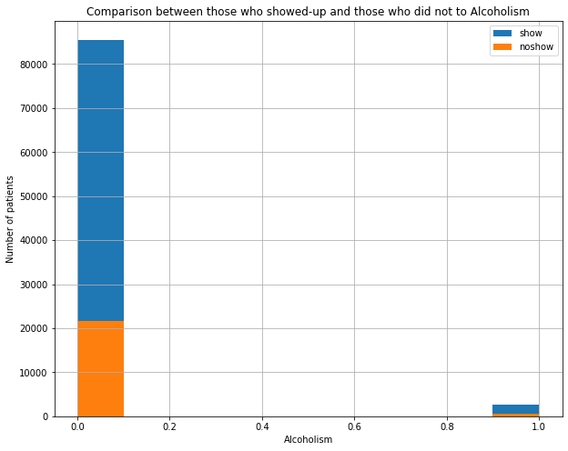

```python
plt.figure(figsize=[10,8])
df.Alcoholism[show].hist(label = 'show')
df.Alcoholism[noshow].hist(label = 'noshow')
plt.legend()

plt.title('Comparison between those who showed-up and those who did not to Alcoholism')
plt.xlabel('Alcoholism')
plt.ylabel('Number of patients');
```

Alcoholism rate is normal

#### 8- Handicap

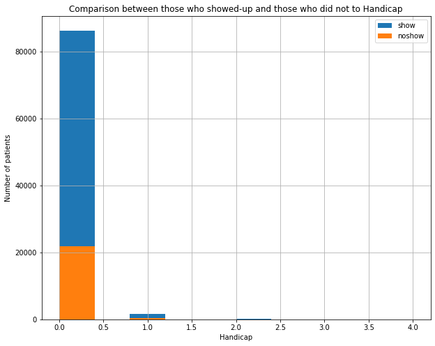

```python
plt.figure(figsize=[10,8])
df.Handicap[show].hist(label = 'show')
df.Handicap[noshow].hist(label = 'noshow')
plt.legend()

plt.title('Comparison between those who showed-up and those who did not to Handicap')
plt.xlabel('Handicap')
plt.ylabel('Number of patients');
```

Handicap rate is normal

#### 9- SMS_received

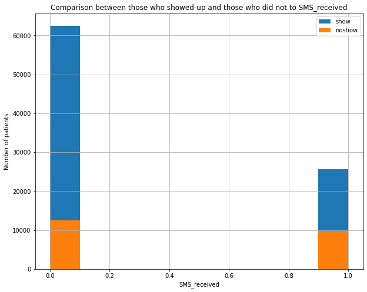

```python
plt.figure(figsize=[10,8])
df.SMS_received[show].hist(label = 'show')
df.SMS_received[noshow].hist(label = 'noshow')
plt.legend()

plt.title('Comparison between those who showed-up and those who did not to SMS_received')
plt.xlabel('SMS_received')
plt.ylabel('Number of patients');
```

It is strange that a large number of those who did receive SMS, showed-up.

## Conclusions

### Limitations

- Not able to address the time dimenion as the appointments times were set to 00:00:00.
- And could not detect direct corrolation between patients showing-up and some characteristics.

## Submitting your Project

> **Tip**: Before you submit your project, you need to create a .html or .pdf version of this notebook in the workspace here. To do that, run the code cell below. If it worked correctly, you should get a return code of 0, and you should see the generated .html file in the workspace directory (click on the orange Jupyter icon in the upper left).

> **Tip**: Alternatively, you can download this report as .html via the **File** > **Download as** submenu, and then manually upload it into the workspace directory by clicking on the orange Jupyter icon in the upper left, then using the Upload button.

> **Tip**: Once you've done this, you can submit your project by clicking on the "Submit Project" button in the lower right here. This will create and submit a zip file with this .ipynb doc and the .html or .pdf version you created. Congratulations!

```python
from subprocess import call
call(['python', '-m', 'nbconvert', 'Investigate_a_Dataset.ipynb'])
```

```
1
```